# Uber Spread Analysis

Joerio Christo Chandra 702302, Priananda Azhar 702299, Syafiq 275407

19-07-2022

### BACKGROUND

As part of our final project for Data Science course (STIS3023), we run several analyses using Uber’s data. Our main objectives are:

- drawing plots
- clustering

### OBJECTIVE

- to get a gist of the Uber service spread based on locations of order
- to find out the trend of customers’ order locations based on day, month, hour

### SOURCE

For this project, we use the Uber data that contains latitude and longitude. It is downloaded from https://data.fivethirtyeight.com/{Five Thirty Eight}.

### DATA PREPARATION

#### Data Reading

In the beningging, we read the dataset first. We are limiting ourselves to using three CSV files for this project, which is the data of Uber orders on months April to June of the year 2014. The data example of the first 5 rows can be seen below.

```r
head(jun_data, 5)
```

```
##          Date.Time     Lat      Lon   Base
## 1 6/1/2014 0:00:00 40.7293 -73.9920 B02512
## 2 6/1/2014 0:01:00 40.7131 -74.0097 B02512
## 3 6/1/2014 0:04:00 40.3461 -74.6610 B02512
## 4 6/1/2014 0:04:00 40.7555 -73.9833 B02512
## 5 6/1/2014 0:07:00 40.6880 -74.1831 B02512
```

#### Preprocessing

Then, in the prepocessing step, we perform the appropriate formatting of Date.Time column. Then, we proceed to create factors like day, month, year and more. After we reformat the Date.Time column, we created each individual column for hour, minute, second, day, month and year. We will combine all of this data into a single dataframe called ‘uber_data’.

```r
#combine 3 dataset of 3 months
uber_data <- rbind(apr_data, may_data, jun_data)

#checking for na values
which(is.na(uber_data$Date.Time))
```

```
## integer(0)
```

```r
which(is.na(uber_data$Lat))
```

```
## integer(0)
```

```r
which(is.na(uber_data$Lon))
```

```
## integer(0)
```

```r
which(is.na(uber_data$Base))
```

```
## integer(0)
```

```r
#Format existing date from the DS into %m/%d/%Y %H:%M:%S
uber_data$Date.Time <- as.POSIXct(uber_data$Date.Time, format = "%m/%d/%Y %H:%M:%S")

#add a new column "Time" with the value of formatted existing "Date.Time" column
uber_data$Time <- format(uber_data$Date.Time, format="%H:%M:%S")

#format to year month day hour minute second
uber_data$Date.Time <- ymd_hms(uber_data$Date.Time)

#add new columns of day, month, year and dayofweek from factor() then day/month/year/etc() to obtain respectively
uber_data$day <- factor(day(uber_data$Date.Time))
uber_data$month <- factor(month(uber_data$Date.Time, label = TRUE))
uber_data$year <- factor(year(uber_data$Date.Time))
uber_data$dayofweek <- factor(wday(uber_data$Date.Time, label = TRUE))

uber_data$hour <- factor(hour(hms(uber_data$Time)))
uber_data$minute <- factor(minute(hms(uber_data$Time)))
uber_data$second <- factor(second(hms(uber_data$Time)))
```

#### DATA ANALYSIS

In the Data analysis step, we will visualize the rides in New York city by creating a geo-plot that will help us to visualize the rides during April until June 2014.

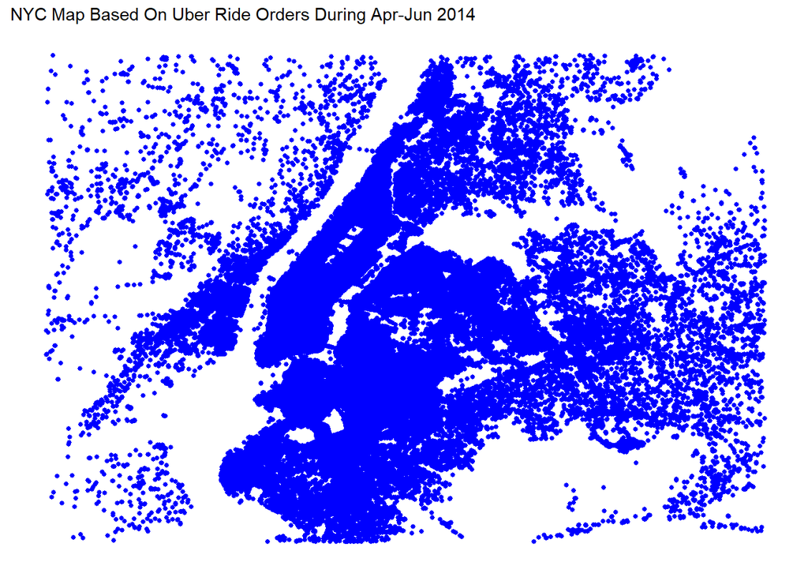

```r
ggplot(uber_data, aes(x=Lon, y=Lat)) +
  geom_point(size=1, color = "blue") +
  scale_x_continuous(limits=c(min_long, max_long)) +
  scale_y_continuous(limits=c(min_lat, max_lat)) +
  theme_map() +
  ggtitle("NYC Map Based On Uber Ride Orders During Apr-Jun 2014")
```

### trips by hours in a day

We use the ggplot function to plot the number of trips made in an hour and dplyr to aggregate the data. From the analysis, we find that the number of trips are higher around 6am to 8am and 3pm to 6pm might due to work/school hours.

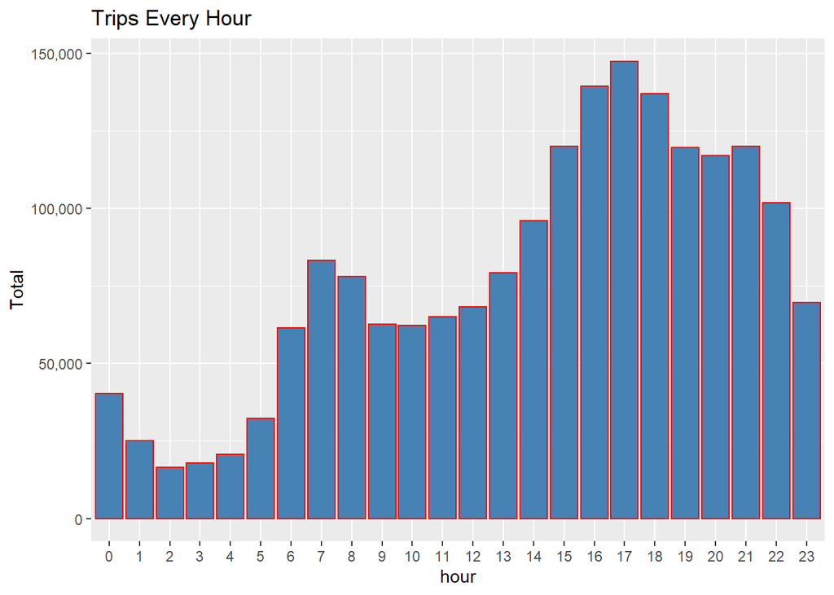

```r
hour_data<-uber_data %>%
  group_by(hour) %>%
  dplyr::summarize(Total = n())

ggplot(hour_data, aes(hour, Total)) +
  geom_bar(stat = "identity", fill = "steelblue", color = "red") +
  ggtitle("Trips Every Hour") +
  theme(legend.position = "none") +
  scale_y_continuous(labels = scales::comma_format())
```

Here we want to visualize how many trips are in a day hours of each month (Apr, May, Jun)

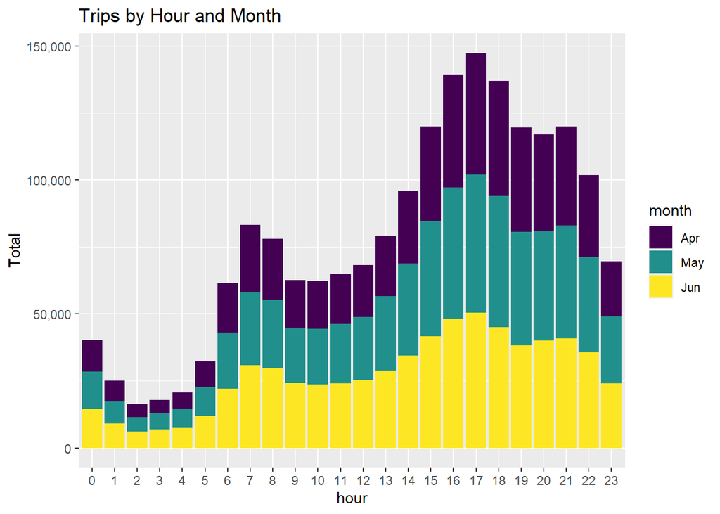

```r
month_hour <- uber_data %>%
  group_by(month, hour) %>%
  dplyr::summarize(Total = n())

ggplot(month_hour, aes(hour, Total, fill = month)) +
  geom_bar(stat = "identity") +
  ggtitle("Trips by Hour and Month") +
  scale_y_continuous(labels = scales::comma_format())
```

### Trips during every day of the month

We plot our data based on every day of the month. From the result, we observe that in April 30th had the highest trip in the year.

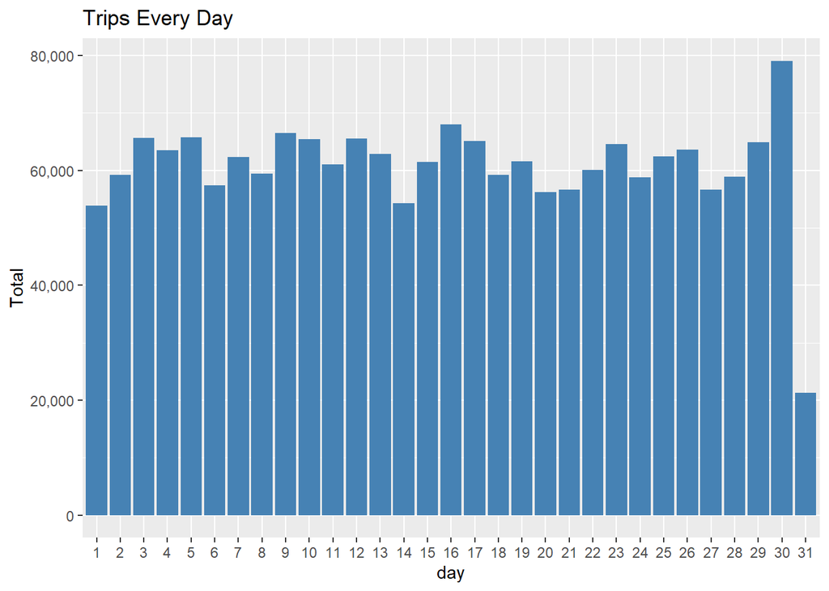

```r
day_group <- uber_data %>%
  group_by(day) %>%
  dplyr::summarize(Total = n())


ggplot(day_group, aes(day, Total)) +
  geom_bar(stat = "identity", fill = "steelblue") +
  ggtitle("Trips Every Day") +
  theme(legend.position = "none") +
  scale_y_continuous(labels = scales::comma_format())
```

### Trips by every day in a month of a year

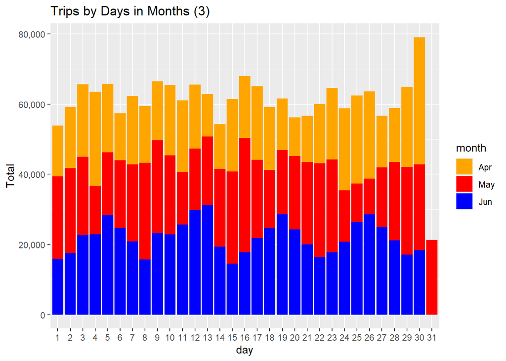

```r
day_month_group <- uber_data %>%
  group_by(month, day) %>%
  dplyr::summarize(Total = n())

ggplot(day_month_group, aes(day, Total, fill = month)) +
  geom_bar( stat = "identity") +
  ggtitle("Trips by Days in Months (3)") +
  scale_y_continuous(labels = scales::comma_format()) +
  scale_fill_manual(values = colors)
```

### Number of trips during months in a year

We visualize the number of trips each month of the year. We found that based on the graph, most of the trips were made during the month of Jun

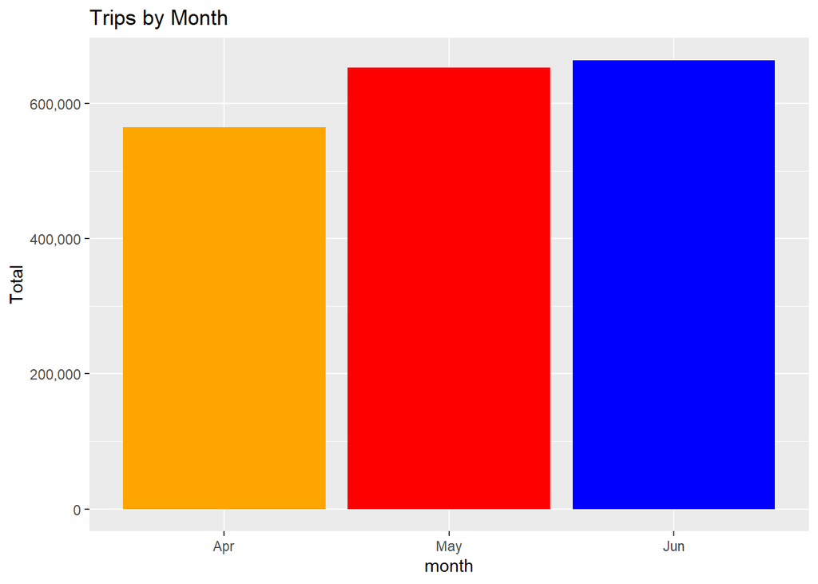

```r
month_group <- uber_data %>%
  group_by(month) %>%
  dplyr::summarize(Total = n())

ggplot(month_group, aes(month, Total, fill = month)) +
  geom_bar( stat = "identity") +
  ggtitle("Trips by Month") +
  theme(legend.position = "none") +
  scale_y_continuous(labels = scales::comma_format()) +
  scale_fill_manual(values = colors)
```

### Trips by dayofweek every month in a year

We plot the number of trips by day and month. Based on our visualization, we observed that in June most of the trip were made. In the month of June, the peak day of the trips is on Thursday.

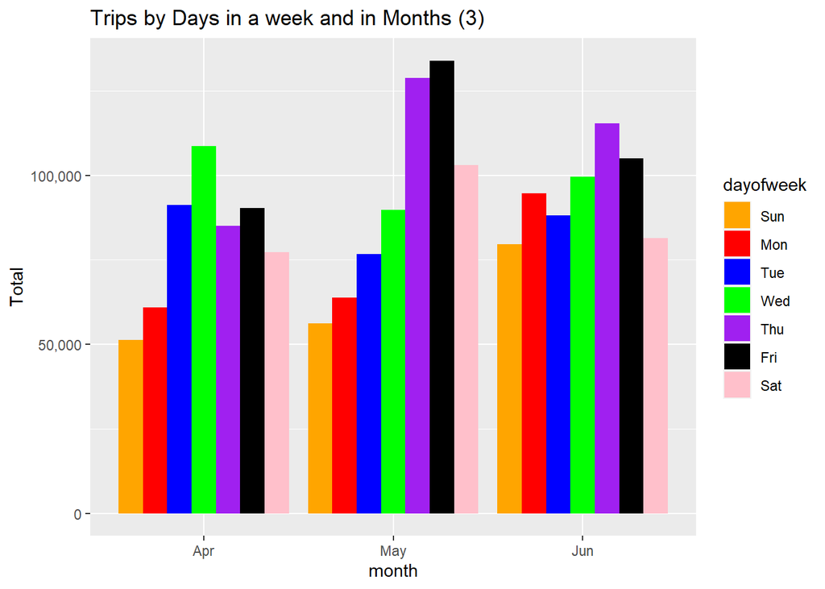

```r
month_weekday <- uber_data %>%
  group_by(month, dayofweek) %>%
  dplyr::summarize(Total = n())

ggplot(month_weekday, aes(month, Total, fill = dayofweek)) +
  geom_bar( stat = "identity", position = "dodge") +
  ggtitle("Trips by Days in a week and in Months (3)") +
  scale_y_continuous(labels = scales::comma_format()) +
  scale_fill_manual(values = colors)
```

### CALCULATING NUMBER OF TRIPS USING BASES

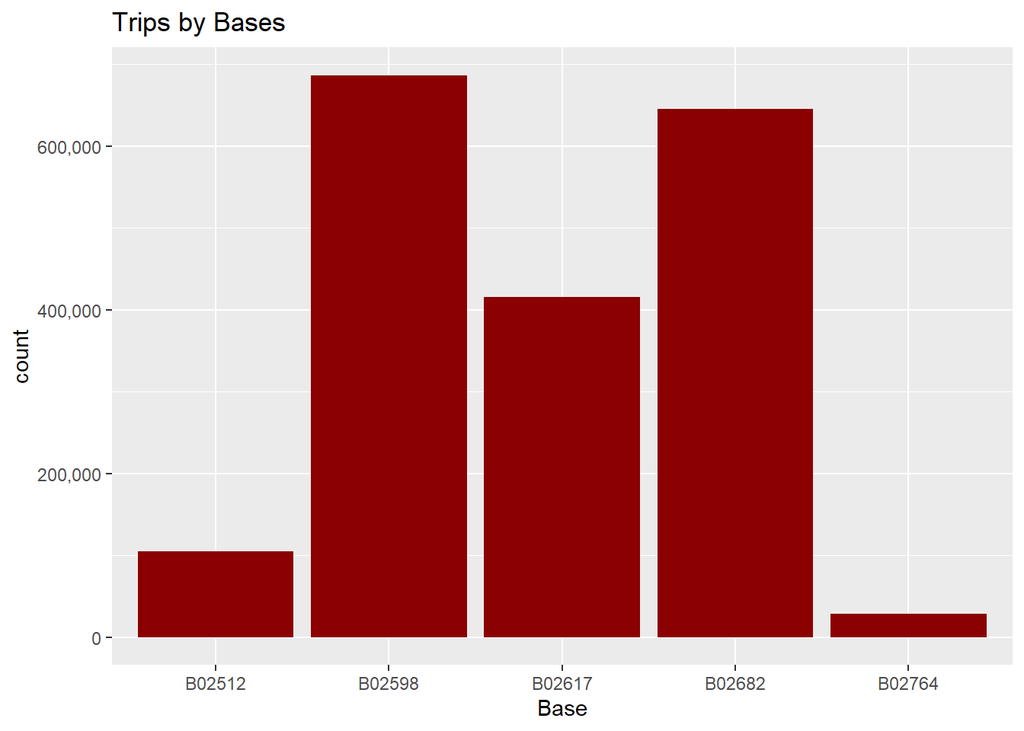

```r
ggplot(uber_data, aes(Base)) +
  geom_bar(fill = "darkred") +
  scale_y_continuous(labels = scales::comma_format()) +
  ggtitle("Trips by Bases")
```

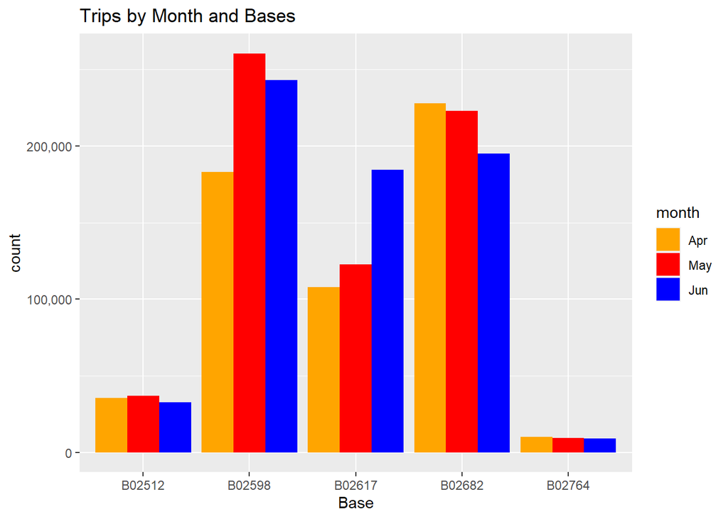

```r
ggplot(uber_data, aes(Base, fill = month)) +
  geom_bar(position = "dodge") +
  scale_y_continuous(labels = scales::comma_format()) +
  ggtitle("Trips by Month and Bases") +
  scale_fill_manual(values = colors)
```

### HeatMap

From heatmap, we can see correlation between each column, here as we see the lighter color has the most correlation between two features. It seems like the B02598 has the highest correlation on the month of may.

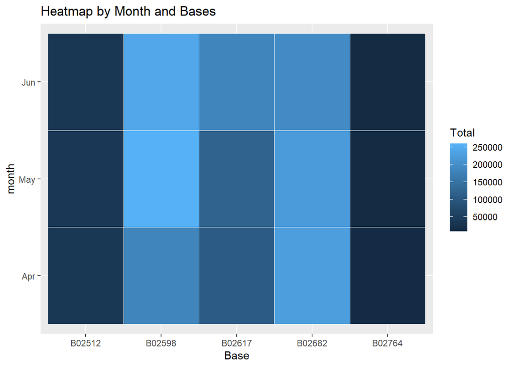

```r
month_base <-  uber_data %>%
  group_by(Base, month) %>%
  dplyr::summarize(Total = n())

ggplot(month_base, aes(Base, month, fill = Total)) +
  geom_tile(color = "white") +
  ggtitle("Heatmap by Month and Bases")
```

### K-MEANS CLUSTERING

```r
clus <- uber_data %>%
  group_by(Lat, Lon) %>%
  dplyr::summarize()
```

```r
k2 <- kmeans(clus, centers = 2, nstart = 25)
str(k2)
```

```
## List of 9
##  $ cluster     : int [1:342521] 1 1 1 1 1 1 1 1 1 1 ...
##  $ centers     : num [1:2, 1:2] 40.7 40.8 -74 -73.8
##   ..- attr(*, "dimnames")=List of 2
##   .. ..$ : chr [1:2] "1" "2"
##   .. ..$ : chr [1:2] "Lat" "Lon"
##  $ totss       : num 3304
##  $ withinss    : num [1:2] 1545 712
##  $ tot.withinss: num 2258
##  $ betweenss   : num 1046
##  $ size        : int [1:2] 314413 28108
##  $ iter        : int 1
##  $ ifault      : int 0
##  - attr(*, "class")= chr "kmeans"
```

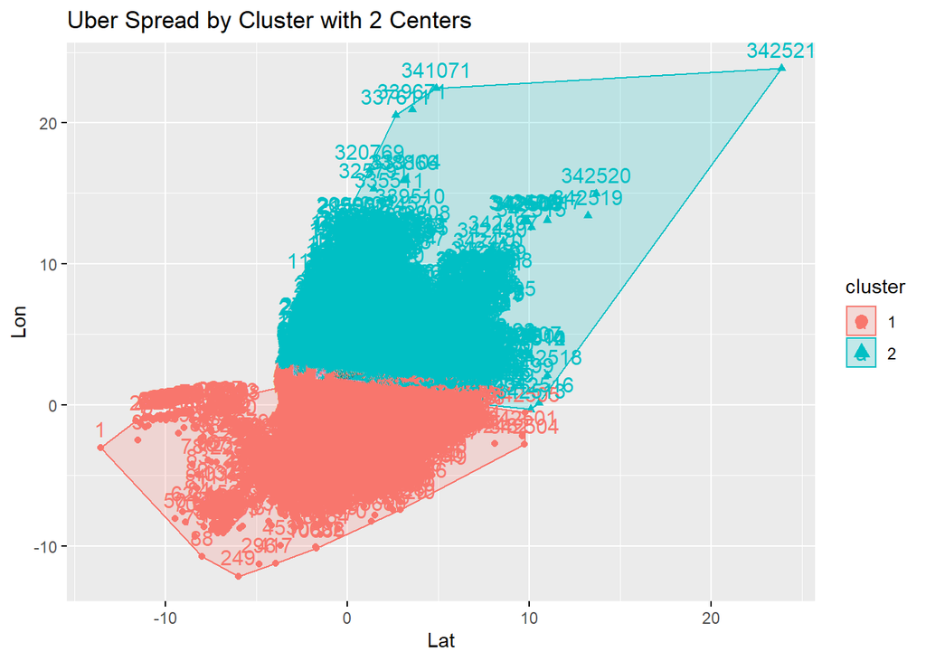

```r
fviz_cluster(k2, data = clus, main = "Uber Spread by Cluster with 2 Centers")
```

### Conclusion

- By using data analysis tools provided in libraries or the langguages basis it self such as Rlang and pyhton really helps in data analysis or creating Machine Learning Model.
- The outcome of this project (HTML) can be accessed by any form of devices such as mobile and PC desktop.
- Data analyzing can be very useful for companies to expand/analyze their business.
- By the availability of tools/libraries we have, made data exploratory simpler and effortless.
- The data are automatically stored by the companies databases from their mobile app/web app to the big data pipeline and can be easily fetched by them to do their own analyzation.